# P2

```python
import pandas as pd
import numpy as np
import seaborn as sns
import matplotlib.pyplot as plt
from pandas import *
import random
```

```python
titanic_data = pd.read_csv('titanic_data.csv')
```

## Questions

Please see the report provided as a pdf file ('Report_p2.pdf') along with this code for detailed questions

## Wrangling

### Checking for missing data and data datatypes

```python
titanic_data.info()
```

```
<class 'pandas.core.frame.DataFrame'>
RangeIndex: 891 entries, 0 to 890
Data columns (total 12 columns):
PassengerId    891 non-null int64
Survived       891 non-null int64
Pclass         891 non-null int64
Name           891 non-null object
Sex            891 non-null object
Age            714 non-null float64
SibSp          891 non-null int64
Parch          891 non-null int64
Ticket         891 non-null object
Fare           891 non-null float64
Cabin          204 non-null object
Embarked       889 non-null object
dtypes: float64(2), int64(5), object(5)
memory usage: 83.6+ KB
```

We see that there are lot of values missing in **Age (177 missing)** and **Cabin (687 missing)** columns and two values missing in **Embarked** column. It is also seen that all the datatypes are interpreted correctly in the dataframe

### Checking for duplicates

```python
duplicate_rows = titanic_data.duplicated()
duplicate_rows.sum()
```

```
0
```

Since sum of True values in duplicate_rows is 0, there are no duplicate rows in this dataset

### Checking for values for each column

[output not shown]

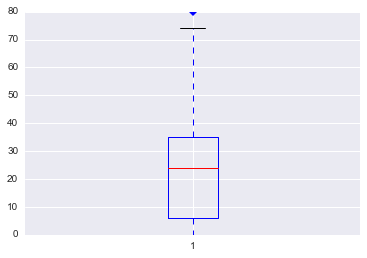

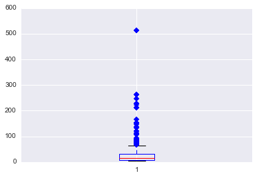

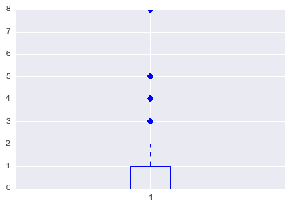

```python
plt.boxplot(titanic_data['Age'].fillna(0),0,'gD')
plt.figure()
plt.boxplot(titanic_data['Fare'],0,'gD')
plt.figure()
plt.boxplot(titanic_data['SibSp'],0,'gD')
```

Checking the numeric columns we see that there are a lot of ouliers in the 'Fare' column. Other data seem to be in order

```python
titanic_data.max()
```

```
PassengerId                            891
Survived                                 1
Pclass                                   3
Name           van Melkebeke, Mr. Philemon
Sex                                   male
Age                                     80
SibSp                                    8
Parch                                    6
Ticket                           WE/P 5735
Fare                               512.329
Cabin                                    T
Embarked                                 S
dtype: object
```

```python
titanic_data.min()
```

```
PassengerId                      1
Survived                         0
Pclass                           1
Name           Abbing, Mr. Anthony
Sex                         female
Age                           0.42
SibSp                            0
Parch                            0
Ticket                      110152
Fare                             0
Cabin                          inf
Embarked                       inf
dtype: object
```

Comparing the datatypes, minimum and maximum values, we see that Fare column has an entry of 0 as the minimum fare, which is suspicious. It needs to be investigated further

```python
titanic_data.query('Fare==0')
```

|  | PassengerId | Survived | Pclass | Name | Sex | Age | SibSp | Parch | Ticket | Fare | Cabin | Embarked |
| --- | --- | --- | --- | --- | --- | --- | --- | --- | --- | --- | --- | --- |
| 179 | 180 | 0 | 3 | Leonard, Mr. Lionel | male | 36.0 | 0 | 0 | LINE | 0.0 | NaN | S |
| 263 | 264 | 0 | 1 | Harrison, Mr. William | male | 40.0 | 0 | 0 | 112059 | 0.0 | B94 | S |
| 271 | 272 | 1 | 3 | Tornquist, Mr. William Henry | male | 25.0 | 0 | 0 | LINE | 0.0 | NaN | S |
| 277 | 278 | 0 | 2 | Parkes, Mr. Francis "Frank" | male | NaN | 0 | 0 | 239853 | 0.0 | NaN | S |
| 302 | 303 | 0 | 3 | Johnson, Mr. William Cahoone Jr | male | 19.0 | 0 | 0 | LINE | 0.0 | NaN | S |
| 413 | 414 | 0 | 2 | Cunningham, Mr. Alfred Fleming | male | NaN | 0 | 0 | 239853 | 0.0 | NaN | S |
| 466 | 467 | 0 | 2 | Campbell, Mr. William | male | NaN | 0 | 0 | 239853 | 0.0 | NaN | S |
| 481 | 482 | 0 | 2 | Frost, Mr. Anthony Wood "Archie" | male | NaN | 0 | 0 | 239854 | 0.0 | NaN | S |
| 597 | 598 | 0 | 3 | Johnson, Mr. Alfred | male | 49.0 | 0 | 0 | LINE | 0.0 | NaN | S |
| 633 | 634 | 0 | 1 | Parr, Mr. William Henry Marsh | male | NaN | 0 | 0 | 112052 | 0.0 | NaN | S |
| 674 | 675 | 0 | 2 | Watson, Mr. Ennis Hastings | male | NaN | 0 | 0 | 239856 | 0.0 | NaN | S |
| 732 | 733 | 0 | 2 | Knight, Mr. Robert J | male | NaN | 0 | 0 | 239855 | 0.0 | NaN | S |
| 806 | 807 | 0 | 1 | Andrews, Mr. Thomas Jr | male | 39.0 | 0 | 0 | 112050 | 0.0 | A36 | S |
| 815 | 816 | 0 | 1 | Fry, Mr. Richard | male | NaN | 0 | 0 | 112058 | 0.0 | B102 | S |
| 822 | 823 | 0 | 1 | Reuchlin, Jonkheer. John George | male | 38.0 | 0 | 0 | 19972 | 0.0 | NaN | S |

```python
##Finding mean Fare for each class
titanic_data.groupby('Pclass')['Fare'].mean()
```

```
Pclass
1    84.154687
2    20.662183
3    13.675550
Name: Fare, dtype: float64
```

```python
def assign_values_toa_column(df,row_list,column,value):
    for i in range(len(row_list)):
        df.loc[row_list[i],column]=value
```

```python
#Replacing 0 values in Fare column with mean values for their respective class
rowlist_firstclass=titanic_data[(titanic_data.Fare==0) & (titanic_data.Pclass==1)].index.tolist()
rowlist_secondclass=titanic_data[(titanic_data.Fare==0) & (titanic_data.Pclass==2)].index.tolist()
rowlist_thirdclass=titanic_data[(titanic_data.Fare==0) & (titanic_data.Pclass==3)].index.tolist()
assign_values_toa_column(titanic_data,rowlist_firstclass,'Fare',84.154687)
assign_values_toa_column(titanic_data,rowlist_secondclass,'Fare',20.662183)
assign_values_toa_column(titanic_data,rowlist_thirdclass,'Fare',13.675550)
```

## Data Exploration

### Travel class vs Survival

```python
groupedby_class=titanic_data.groupby(['Pclass','Survived']).size()
titanic_data.groupby(['Pclass','Survived']).size()
```

```
Pclass  Survived
1       0            80
        1           136
2       0            97
        1            87
3       0           372
        1           119
dtype: int64
```

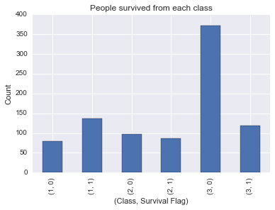

```python
%matplotlib inline
g=groupedby_class.plot.bar(title='People survived from each class')
g.set_xlabel("(Class, Survival Flag)")
g.set_ylabel("Count")
```

### Effect of Fare

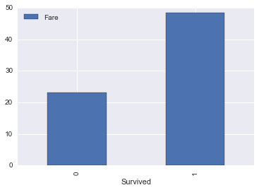

```python
Fare_grouped = titanic_data.groupby('Survived')['Fare'].mean()
Fare_grouped.plot.bar(legend=True)
```

This graph shows the mean fare of tickets for passengers who survived and who didn't survive. It is similiar to the one with travel class seen before and has the same correlation. Higher class travel would have warrented higher fare. Passengers who purchased expensive tickets seem to have survived more than those with cheaper tickers.

### Age vs Survival

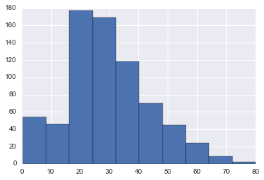

```python
titanic_data['Age'].hist()
```

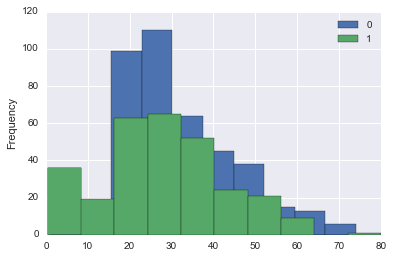

```python
age_grouped = titanic_data.groupby('Survived')['Age']
plot=age_grouped.plot.hist(legend=True)
```

The mode is at around 20-30 years for both groups

```python
#Creating dataframes for male and female according to Age and Survival data

def dataframe_fillvalues(df,gender):
    index=['<=10','11-20','21-30','31-40','41-50','51-60','61-70','>70']
    columns=['Not Survived Count','Survived Count']
    df_to_fill=pd.DataFrame(index=index,columns=columns)
    pd.to_numeric(df_to_fill['Survived Count'],errors='coerce')
    pd.to_numeric(df_to_fill['Not Survived Count'], errors='coerce')
    df_to_fill['Survived Count']=0
    df_to_fill['Not Survived Count']=0

    for i,row in df.iterrows():
        if (row['Age']<=10 and row['Sex']==gender):
            if row['Survived']==1:
                df_to_fill.loc['<=10','Survived Count'] = df_to_fill.loc['<=10','Survived Count'] + 1
            else:
                df_to_fill.loc['<=10','Not Survived Count'] = df_to_fill.loc['<=10','Not Survived Count'] + 1
        elif (row['Age']>10 and row['Age']<=20 and row['Sex']==gender):
            if row['Survived']==1:
                df_to_fill.loc['11-20','Survived Count'] = df_to_fill.loc['11-20','Survived Count'] + 1
            else:
                df_to_fill.loc['11-20','Not Survived Count'] = df_to_fill.loc['11-20','Not Survived Count'] + 1
        elif (row['Age']>20 and row['Age']<=30 and row['Sex']==gender):
            if row['Survived']==1:
                 df_to_fill.loc['21-30','Survived Count'] =  df_to_fill.loc['21-30','Survived Count'] + 1
            else:
                 df_to_fill.loc['21-30','Not Survived Count'] =  df_to_fill.loc['21-30','Not Survived Count'] + 1
        elif (row['Age']>30 and row['Age']<=40 and row['Sex']==gender):
            if row['Survived']==1:
                df_to_fill.loc['31-40','Survived Count'] = df_to_fill.loc['31-40','Survived Count'] + 1
            else:
                df_to_fill.loc['31-40','Not Survived Count'] = df_to_fill.loc['31-40','Not Survived Count'] + 1
        elif (row['Age']>40 and row['Age']<=50 and row['Sex']==gender):
            if row['Survived']==1:
                df_to_fill.loc['41-50','Survived Count'] = df_to_fill.loc['41-50','Survived Count'] + 1
            else:
                df_to_fill.loc['41-50','Not Survived Count'] = df_to_fill.loc['41-50','Not Survived Count'] + 1
        elif (row['Age']>50 and row['Age']<=60 and row['Sex']==gender):
            if row['Survived']==1:
                df_to_fill.loc['51-60','Survived Count'] = df_to_fill.loc['51-60','Survived Count'] + 1
            else:
                df_to_fill.loc['51-60','Not Survived Count'] = df_to_fill.loc['51-60','Not Survived Count'] + 1
        elif (row['Age']>60 and row['Age']<=70 and row['Sex']==gender):
            if row['Survived']==1:
                df_to_fill.loc['61-70','Survived Count'] = df_to_fill.loc['61-70','Survived Count'] + 1
            else:
                df_to_fill.loc['61-70','Not Survived Count'] = df_to_fill.loc['61-70','Not Survived Count'] + 1
        elif (row['Age']>70 and row['Sex']==gender):
            if row['Survived']==1:
                df_to_fill.loc['>70','Survived Count'] = df_to_fill.loc['>70','Survived Count'] + 1
            else:
                df_to_fill.loc['>70','Not Survived Count'] = df_to_fill.loc['>70','Not Survived Count'] + 1
    return df_to_fill
```

```python
male_df=dataframe_fillvalues(titanic_data,'male')
female_df=dataframe_fillvalues(titanic_data,'female')
```

```python
age_grouped_df = male_df + female_df
age_grouped_df # Data for some passengers is missing from this dataframe since Age data is not available to classify them
```

|  | Not Survived Count | Survived Count |
| --- | --- | --- |
| <=10 | 26 | 38 |
| 11-20 | 71 | 44 |
| 21-30 | 146 | 84 |
| 31-40 | 86 | 69 |
| 41-50 | 53 | 33 |
| 51-60 | 25 | 17 |
| 61-70 | 13 | 4 |
| >70 | 4 | 1 |

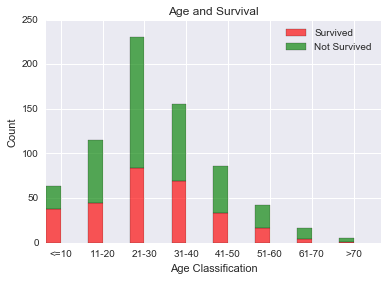

```python
index=np.array(range(8))
width=0.35
plt.bar(index, age_grouped_df['Survived Count'],width=0.35,alpha=0.65, color='r',label='Survived')
plt.bar(index, age_grouped_df['Not Survived Count'], bottom=age_grouped_df['Survived Count'],width=0.35,alpha=0.65, color='g',label='Not Survived')
plt.xlabel('Age Classification')
plt.ylabel('Count')
plt.xticks(index+0.35,age_grouped_df.index)
plt.legend(loc='best')
plt.title('Age and Survival')
```

### Sex vs Survival

```python
sex_grouped_data = titanic_data.groupby(['Sex','Survived']).size().reset_index(name='Count')
sex_grouped_data
```

|  | Sex | Survived | Count |
| --- | --- | --- | --- |
| 0 | female | 0 | 81 |
| 1 | female | 1 | 233 |
| 2 | male | 0 | 468 |
| 3 | male | 1 | 109 |

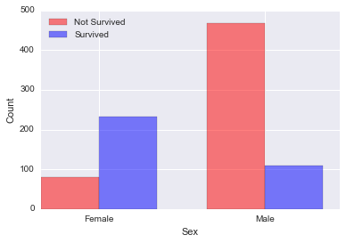

```python
index=np.array(range(2))
plt.bar(index,sex_grouped_data[sex_grouped_data.Survived==0]['Count'],width=0.35,alpha=0.5, color='r',label='Not Survived')
plt.bar(index+0.35,sex_grouped_data[sex_grouped_data.Survived==1]['Count'], width=0.35,alpha=0.5,color='b',label='Survived')
plt.xlabel('Sex')
plt.ylabel('Count')
plt.xticks(index+0.35,('Female','Male'))
plt.legend(loc='best')
```

This graph shows two things. One is that male passengers were more than female passengers. Second is that the ratio of survival is high for females whereas only a fraction of males seem to have survived.

### Age and Sex Combined Analysis

Till now we have seen that demographics of passengers has a major correlation with the variable 'Survived'. To go deeper, we will classify passengers according to age and sex and plot a bar graph to visualize the results.

```python
female_df
```

|  | Not Survived Count | Survived Count |
| --- | --- | --- |
| <=10 | 12 | 19 |
| 11-20 | 12 | 34 |
| 21-30 | 20 | 61 |
| 31-40 | 9 | 46 |
| 41-50 | 10 | 21 |
| 51-60 | 1 | 13 |
| 61-70 | 0 | 3 |
| >70 | 0 | 0 |

[figure not shown]

```python
index=np.array(range(8))
width=0.35
plt.bar(index, male_df['Survived Count'],width=0.35,alpha=0.65, color='r',label='Male Survived')
plt.bar(index, male_df['Not Survived Count'], bottom=male_df['Survived Count'],width=0.35,alpha=0.65, color='g',label='Male Not Survived')
plt.bar(index+0.35, female_df['Survived Count'],width=0.35,alpha=0.65, color='y',label='Female Survived')
plt.bar(index+0.35, female_df['Survived Count'],bottom=female_df['Survived Count'], width=0.35,alpha=0.65, color='b',label='Female Not Survived')
plt.xlabel('Age Classification')
plt.ylabel('Count')
plt.xticks(index+0.35,male_df.index)
plt.legend(loc='best')
plt.title('Age and Sex Combined')
```

It is clear that young passengers and ladies have been given preference for survival. Further statistical tests are needed to prove causation.

### Effect of Family on Survival

```python
SibSp_grouped=titanic_data.groupby(['SibSp','Survived']).size()
SibSp_grouped_df=SibSp_grouped.reset_index(name='Count') #converting to dataframe
```

```python
#adding percentage column to the above grouped data after converting it to a dataframe

SibSp_grouped_df['Percent Survived']=0.0 #initialising to zero

def sum_count(column_to_look, value_to_look, df):
    sum=0.0
    for i,row in df.iterrows():
        if (row[column_to_look]==value_to_look):
            sum = sum + row['Count']
    return sum

def add_percentage(df,column_to_look):
    for i,row in df.iterrows():
        sumcount=sum_count(column_to_look, row[column_to_look],df)
        df.loc[i,'Percent Survived']=(row['Count']/sumcount) * 100
    return df

SibSp_grouped_df=add_percentage(SibSp_grouped_df, 'SibSp')
SibSp_grouped_df[SibSp_grouped_df.Survived==1]
```

|  | SibSp | Survived | Count | Percent Survived |
| --- | --- | --- | --- | --- |
| 1 | 0 | 1 | 210 | 34.539474 |
| 3 | 1 | 1 | 112 | 53.588517 |
| 5 | 2 | 1 | 13 | 46.428571 |
| 7 | 3 | 1 | 4 | 25.000000 |
| 9 | 4 | 1 | 3 | 16.666667 |

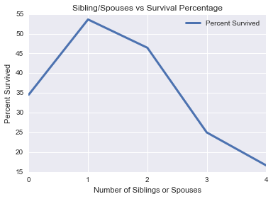

```python
#Plotting the above dataframe

plt.plot(SibSp_grouped_df[SibSp_grouped_df.Survived==1]['SibSp'], SibSp_grouped_df[SibSp_grouped_df.Survived==1]['Percent Survived'], linewidth=3.0)
plt.xlabel('Number of Siblings or Spouses')
plt.ylabel('Percent Survived')
plt.title('Sibling/Spouses vs Survival Percentage')
plt.xticks((0,1,2,3,4))
plt.legend()
```

```python
#Same procedure like SibSp_grouped_df followed for 'Parch' data
Parch_grouped=titanic_data.groupby(['Parch','Survived']).size()
Parch_grouped_df=Parch_grouped.reset_index(name='Count')
SibSp_grouped_df['Percent Survived']=0.0
Parch_grouped_df=add_percentage(Parch_grouped_df, 'Parch')
Parch_grouped_df[Parch_grouped_df.Survived==1]
```

|  | Parch | Survived | Count | Percent Survived |
| --- | --- | --- | --- | --- |
| 1 | 0 | 1 | 233 | 34.365782 |
| 3 | 1 | 1 | 65 | 55.084746 |
| 5 | 2 | 1 | 40 | 50.000000 |
| 7 | 3 | 1 | 3 | 60.000000 |
| 10 | 5 | 1 | 1 | 20.000000 |

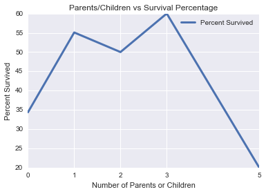

```python
plt.plot(Parch_grouped_df[Parch_grouped_df.Survived==1]['Parch'], Parch_grouped_df[Parch_grouped_df.Survived==1]['Percent Survived'], linewidth=3.0)
plt.xlabel('Number of Parents or Children')
plt.ylabel('Percent Survived')
plt.title('Parents/Children vs Survival Percentage')
plt.xticks((0,1,2,3,5))
plt.legend()
```

There is some sort of relationship of the variables 'Sibsp' and'Parch' with 'Survived', but is not quite clear. In case of 'SibSp', the survival percentage increases when the number of spouses or siblings is one, when the value is more than that the survival percentage decreases drastically.

The graph of 'Parch' has high percentage when the value is between one and three, otherwise the percentage of survival is quite low. No major conclusion can be drawn from this analysis

### Two-proportions Z-test

#### Z-test for Demographics of Passenger (Age and Sex)

```python
def z_test_two_proportions(p1,p2,n1,n2):
    p = (p1 * n1 + p2 * n2) / (n1 + n2)
    SE = np.sqrt( p * ( 1 - p ) * ( (1/n1) + (1/n2) ) )
    z = (p1 - p2) / SE
    print z
    z_critical=1.65
    if z > z_critical:
        print 'Test significant at p < 0.05'
    else:
        print 'Not Significant'
```

```python
#One tail z-test
#sample 1 of people whose age was less than or equal to 10 and gender was female
s1=titanic_data[(titanic_data.Age<=10) & (titanic_data.Sex=='female')]['Survived']
p1=sum(s1)/float(len(s1))
n1=31.0
n2=35.0
# Random sample of 35 passengers from the entire population
s2=random.sample(titanic_data['Survived'],35)
p2=sum(s2)/float(len(s2))
```

```python
z_test_two_proportions(p1,p2,n1,n2)
```

```
2.9185933552
Test significant at p < 0.05
```

#### Z-test for Passenger Class

```python
#One tail z-test
#random sample of first class passengers
s1=random.sample(titanic_data[titanic_data.Pclass==1]['Survived'],35)
p1=sum(s1)/float(len(s1))
n1=35.0
n2=35.0
#random sample of 35 passengers from entire population
s2=random.sample(titanic_data['Survived'],35)
p2=sum(s2)/float(len(s2))
```

```python
z_test_two_proportions(p1,p2,n1,n2)
```

```
1.684356084
Test significant at p < 0.05
```